# ASSIGNMENT 2 (for 30/31.03.2022)

Marian Nehrebecki

3/29/2022

### A brief description

> (From the Wikipedia) **The Middle** is an American television sitcom that premiered on September 30, 2009, on ABC, and concluded on May 22, 2018. The series follows an Indiana residing lower middle class family living and facing the day-to-day struggles of home life, work, and raising children. The series stars *Patricia Heaton* and *Neil Flynn*. The Middle was created by former *Roseanne* and *Murphy Brown* writers *Eileen Heisler* and *DeAnn Heline* of Blackie and Blondie Productions. The show is produced by *Warner Bros*. Television and Blackie and Blondie Productions. The Middle was praised by television critics and earned numerous award nominations.

> A spin-off of the series, centered around *Eden Sher’s* character, *Sue Heck*, was set to launch in 2019. However, ABC passed on the project. It was shopped to other networks but was never picked up.

### A summary of some basic statistics

**Table 1.** Basic statistics about seasons

| Season | Episodes | Rank (viewers) | Viewers (in millions) |
| --- | --- | --- | --- |
| 1 | 24 | 68 | 6.69 |
| 2 | 24 | 51 | 8.08 |
| 3 | 24 | 60 | 8.08 |
| 4 | 24 | 45 | 8.42 |
| 5 | 24 | 44 | 8.24 |
| 6 | 24 | 53 | 8.68 |
| 7 | 24 | 53 | 8.15 |
| 8 | 23 | 53 | 7.02 |
| 9 | 24 | 53 | 7.28 |

**Comments:**

### The viewership over time

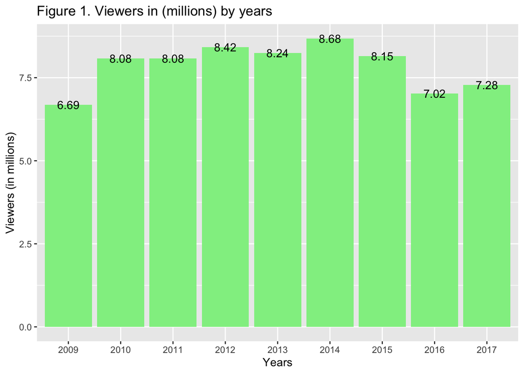

**Comments:**

### The season-to-season changes in viewership

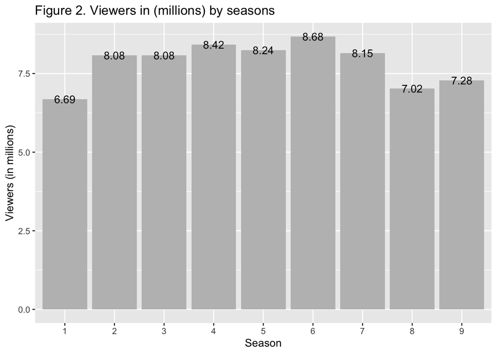

**Comments:**

1. The average number of viewers was 7.85 in millions.
2. The median number of viewers was 8.08 in millions.